# Project 2

### Background

##### The DataSet

Our question for this model is, If Steph Curry scores 30 points in a playoff game, does his team(Warriors) win?

### Logistic Model

To model the probability of the Warriors winning a game with Steph Curry’s scoring, we could apply the logistic regression model
$$P(Y_i = 1|x_i) = \frac{e^{\beta_0+\beta_1 x_i}}{1+e^{\beta_0 + \beta_1 x_i}} = \pi_i$$
where for observation $i$:

- $Y_i = 1$ denotes a win for the Warriors,
- $Y_i=0$ denotes a loss, and
- $x_i$ denotes the points that Steph Curry scored.

Note that if $\beta_1$ is zero in the above model, then $x_i$ (points) provides no insight about the probability of a win. Thus, we could test the hypothesis that

$$H_0: \beta_1 = 0 \\
H_a: \beta_1 \neq 0$$

## Analysis

### Fitting the Model

In order to calculate $\beta_0$ and $\beta_1$ for the data, we apply the following regression.

```r
SC1.glm <- glm(V2 ~ V3, data=StCu, family=binomial)
pander(summary(SC1.glm))
```

|  | Estimate | Std. Error | z value | Pr(>\|z\|) |
| --- | --- | --- | --- | --- |
| **V3** | 0.1577 | 0.06501 | 2.426 | 0.01525 |
| **(Intercept)** | -3.313 | 1.651 | -2.006 | 0.04484 |

(Dispersion parameter for binomial family taken to be 1 )

| Null deviance: | 47.40 on 37 degrees of freedom |
| --- | --- |
| Residual deviance: | 39.32 on 36 degrees of freedom |

With this information we are able to get the estimated model for $\pi_i$. This is …
$$P(Y_i = 1|x_i) \approx \frac{e^{-3.313+0.1577 x_i}}{1+e^{-3.313+0.1577 x_i}} = \hat{\pi}_i$$
Where $b_0 = -3.313$ is the value of the `(Intercept)` which estimates $\beta_0$ and $b_1 = 0.1577$ is the value of `V3`/`Score` which estimates $\beta_1$.

The $p$-value for the test of `V3`/`Score` shows a significant result $(p = 0.01525)$, because it is lower than 0.05, giving us sufficient evidence to say that $\beta_1 \neq 0$, which allows us to make the inference that Steph Curry’s scoring effects the probability of a wind for the Warriors.

### Vizualizing the Model

In order to see what this looks like, we will make a plot that shows the logistic curve and allows us to visualize what we are doing.

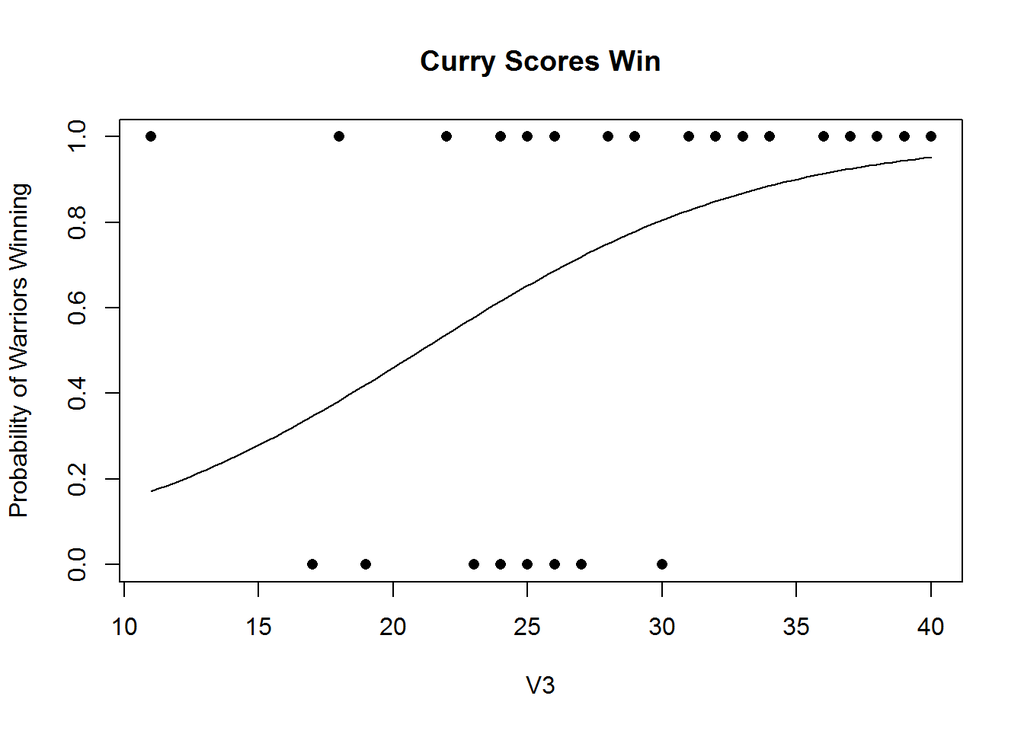

```r
plot(V2 ~ V3, data=StCu, main="Curry Scores Win", ylab='Probability of Warriors Winning', pch=16)
curve(exp(-3.313+0.1577*x)/(1+exp(-3.313+0.1577*x)), from=11, to=40, add=TRUE)
```

### Diagnosing the Model

In order to find out if the logistic regression is a good fit to these data we apply the Hosmer-Lemeshow goodness of fit test.

```r
pander(hoslem.test(SC1.glm$y, SC1.glm$fitted, g=6))
```

Hosmer and Lemeshow goodness of fit (GOF) test: `SC1.glm$y, SC1.glm$fitted`

| Test statistic | df | P value |
| --- | --- | --- |
| 1.957 | 4 | 0.7437 |

The null hypothesis is that the logistic regression is a good fit for the data, with the p-value being 0.7437 we are able to claim that the logistic regression is appropriate.

### Interpretation

```r
pander(predict(SC1.glm, data.frame(V3=30), type='response'))
```

| 1 |
| --- |
| 0.8053 |

This shows us that if Steph Curry scores 30 in a playoff game, his team has a probability of 0.8053 of winning. What if we increase this to 35?

```r
pander(predict(SC1.glm, data.frame(V3=35), type='response'))
```

| 1 |
| --- |
| 0.901 |

….and if we go the opposite direction….

```r
pander(predict(SC1.glm, data.frame(V3=20), type='response'))
```

| 1 |
| --- |
| 0.4606 |